# Monte Carlo analysis of Bitcoin

Lukas Läderach

# Abstract

This document describes the process of modeling a bitcoin monte carlo chart.

# Prerequisites

To follow along this notebook make sure the following R-Packages are installed globally.

```r
# Quandl - Get millions of financial and economic datasets from hundreds of publishers directly into R.
#install.packages("Quandl")
# ggplot2 is a plotting system for R, based on the grammar of graphics.
#install.packages("ggplot2")
```

Once those packages are installed import them into your current workspace and set your Quandl API-Key (You have to create an account at [Quandl](https://www.quandl.com/sign-up-modal?defaultModal=showSignUp)).

```r
library(Quandl)
```

```r
library(ggplot2)

Quandl.api_key("CYyznmeKqzV2GxrHZMxD")
```

Once everthing is set up correctly you should be able retrieve financial data via Quandl.

For example the following statement will retrieve all the BTC/USD starting from 2016-1-1 to the very recent.

```r
startDate = "2016-1-1"
asset = "BITFINEX/BTCUSD"

#data <- Quandl("BITFINEX/BTCUSD", start_date=startDate)
data <- Quandl(asset, start_date=startDate)
head(data)
```

|  | Date | High | Low | Mid | Last | Bid | Ask | Volume |
| --- | --- | --- | --- | --- | --- | --- | --- | --- |
| 1 | 2018-06-14 | 6736.521 | 6269.500 | 6591.55 | 6591.6 | 6591.5 | 6591.6 | 31557.155 |
| 2 | 2018-06-13 | 6611.700 | 6107.877 | 6324.25 | 6324.3 | 6324.2 | 6324.3 | 47211.731 |
| 3 | 2018-06-12 | 6899.000 | 6436.100 | 6525.95 | 6527.4 | 6525.9 | 6526.0 | 31377.131 |
| 4 | 2018-06-11 | 6821.100 | 6629.700 | 6768.35 | 6768.4 | 6768.3 | 6768.4 | 21992.760 |
| 5 | 2018-06-10 | 7614.800 | 6618.900 | 6697.15 | 6697.1 | 6697.1 | 6697.2 | 57671.863 |
| 6 | 2018-06-09 | 7685.000 | 7570.468 | 7582.95 | 7583.0 | 7582.9 | 7583.0 | 5034.321 |

To generate a plot visualizing the closing price according to it’s date (column labeled *Last*) we can specify which columns to retrieve via the column_index parameter (0 is always the *Date* column). To specifiy multiple columns we can also create a vector e.g. *c(4,6)* - this would return a table containing the *Date*, *Last* and *Ask* columns only.

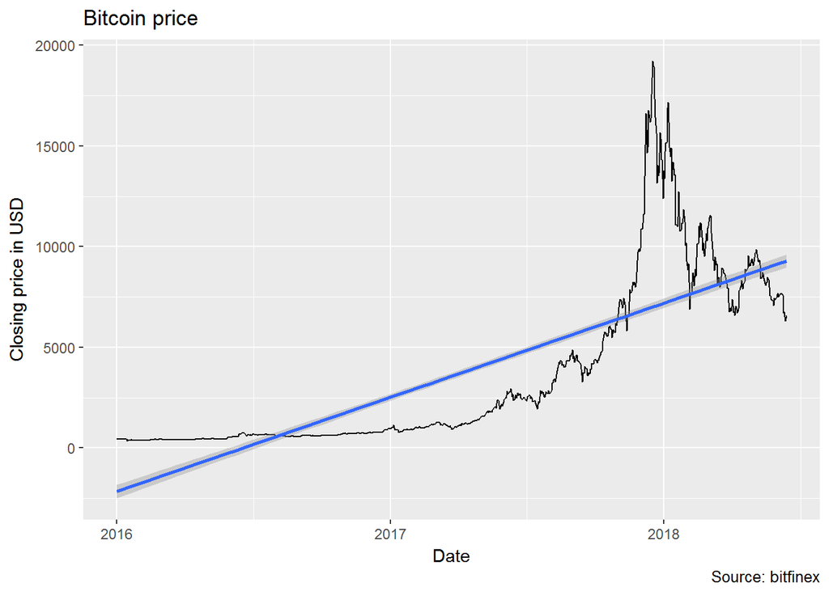

# Introduction

## Brownian Motion

**Main Idea** - There are two parts to random movement

- Deterministic Component, known as Drift
- Stochastic Component, known as Random Shock

Therefore we can predict possible future prices with the following formula

```
Future Price = Today's Price * Continuous Growth over time + volatility of People randomly trading over time
```

We can simulate those random walks, in the following example we create 1000 simulation with prices for the next 150 days.

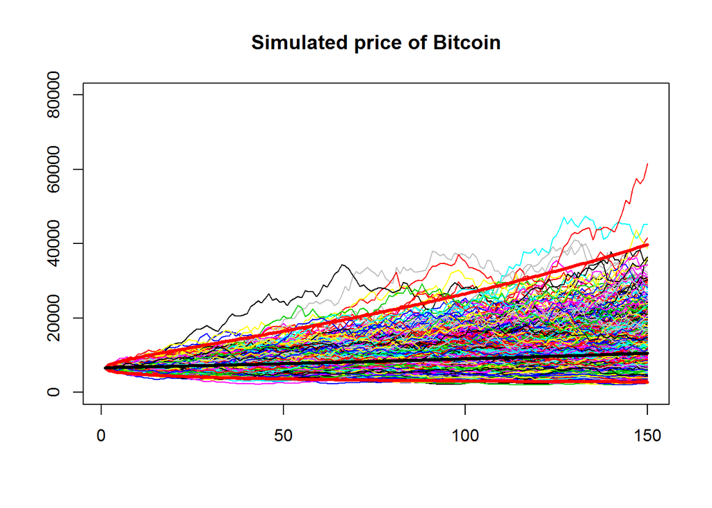

```r
gg = Quandl(asset, start_date=startDate, transform = "rdiff")
lmtRets = gg$Last
mu = mean(lmtRets) # also knwon as Drift
sigma = sd(lmtRets)

nSim = 1000
nDays = 150
S0 <- first(data)$Last
S = matrix(0,nrow=nDays,ncol=nSim)

for (i in 1:nSim) {
  SVec = rep(0, nDays)
  SVec[1] = S0
  for(j in 2:nDays) {
    pastDay = SVec[j-1]
    DeltaS = mu*pastDay + sigma*pastDay*rnorm(1)
    SVec[j] = pastDay+DeltaS
  }
  S[,i] = SVec
}

# Calculating our borders
mean = mu * nDays
sigmaPeak = sigma * sqrt(nDays)
t = seq(from=0,to=1,length.out=nDays)
meanBnd = vector(length = nDays)
upBnd = vector(length = nDays)
loBnd = vector(length = nDays)
test = vector(length = nDays)
for(i in 0:nDays) {
  meanBnd[i] = S0*exp(((mean-sigmaPeak^2/2))*t[i])
  upBnd[i] = S0*exp(((mean-sigmaPeak^2/2))*t[i] + (sigmaPeak * 2.5 * sqrt(t[i])))
  loBnd[i] = S0*exp(((mean-sigmaPeak^2/2))*t[i] + (sigmaPeak * -2.5 * sqrt(t[i])))
}

matplot(S, type='l',col=1:100, lty=1,ylab="",ylim=c(0,80000), main="Simulated price of Bitcoin")
  matlines(loBnd,lwd=3,col="red")
  matlines(upBnd,lwd=3,col="red")
  matlines(meanBnd,lwd=3,col="black")
```

## Lognormal Distribution

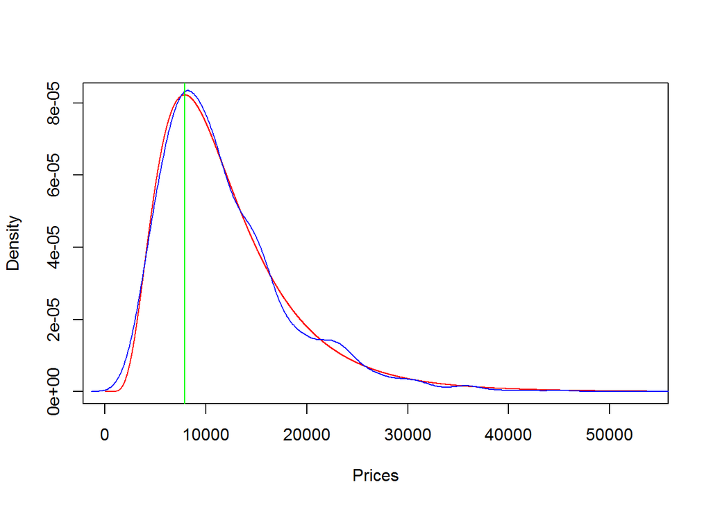

```r
lnMean = S0*exp(mu*nDays)
lnSD = S0*exp(mu*nDays)*sqrt(exp((sigma^2)*nDays)-1)

meanOfLog = log(S0) + (mu-(sigma^2)/2)*nDays
sdOfLog = sigma*sqrt(nDays)
priceGrid = seq(0,lnMean+6*lnSD,length=10000)
theoreticalDens = dlnorm(priceGrid,meanOfLog,sdOfLog)
empiricalDens = density(S[nDays,])

df <- data.frame(priceGrid, theoreticalDens)
maxIndex = which(df$theoreticalDens == max(df$theoreticalDens))
plot(priceGrid, theoreticalDens, type='l', col='red',xlab='Prices', ylab='Density')
  lines(empiricalDens,col='blue')
  abline(v = df$priceGrid[maxIndex], col='green')
```

According to this the highest price probability is

```
## 7908.125
```

# Call option price

```r
K = S0*1.1                                # Strike price
cat("Strike price:", K)
```

```
## Strike price: 7250.76
```

```r
rate = mu                                   # Risk freee rate
c_mc = mean(max(S[nDays,]-K, 0))*exp(-rate)    # Call price Monte Carlo
cat("call price monte carlo", c_mc)
```

```
## call price monte carlo 54036.46
```

# Call price according to Black-Scholes

```r
d1 = (log(S0/K) + (rate+sigma^2/2))/sigma
d2 = (log(S0/K) + (rate-sigma^2/2))/sigma
c_bs = S0*pnorm(d1)-K*pnorm(d2)*exp(-rate)
cat("c_bs:", c_bs)
```

```
## c_bs: 1.944145
```